# Analyzing Individual BGG Users

Phil Henrickson

2022-01-02

# **oiledgladiator’s** BoardGameGeek Collection

This notebook contains a set of analyses for the selected user’s boardgamegeek collection. The bulk of the analysis is focused on building a user-specific predictive model to predict the games that oiledgladiator is likely to own. This enables to ask questions like, based on the games the user currently owns, what games are a good fit for their collection? What upcoming games are they likely to purchase?

This analysis is based on data from BoardGameGeek that was last updated on **2021-12-20.**

# 1 Collection Overview

We can look at a basic description of the number of games that the user owns, has rated, has previously owned, etc.

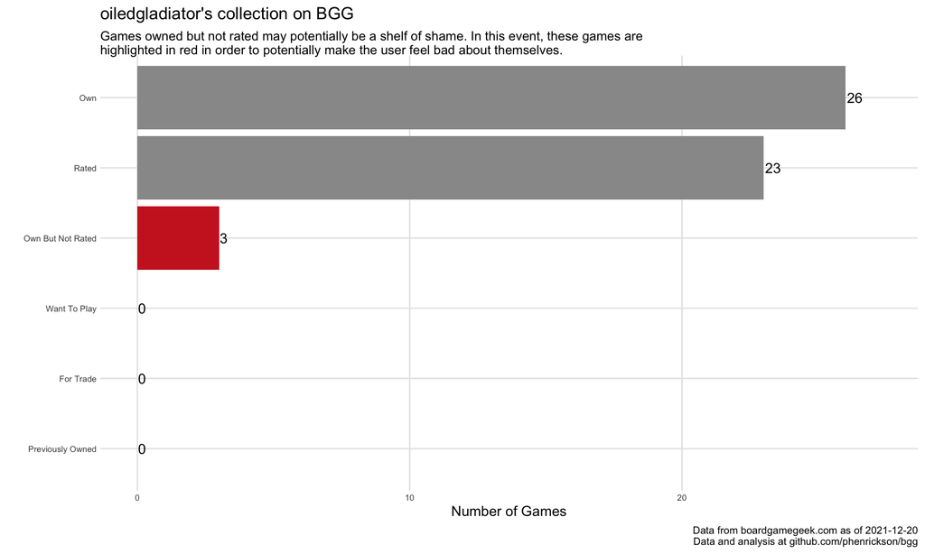

What years has the user owned/rated games from? While we can’t see when a user added or removed a game from their collection, we can look at their collection by the years in which their games were published.

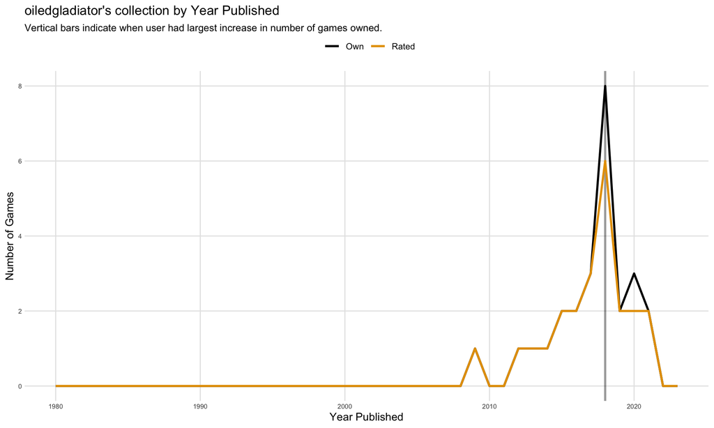

## 1.1 What types of games does oiledgladiator own?

We can look at the most frequent types of categories, mechanics, designers, and artists that appear in a user’s collection.

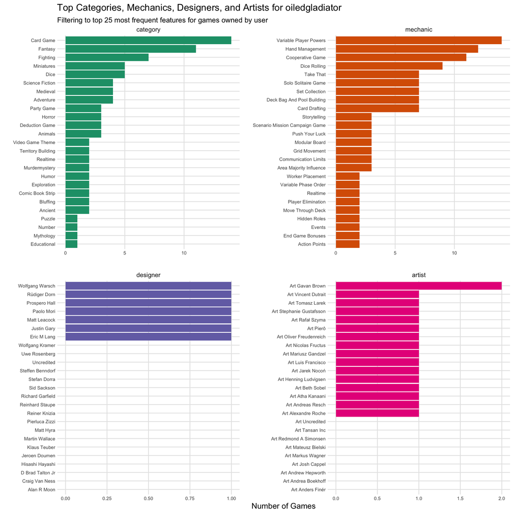

# 2 Modeling **oiledgladiator’s** Collection

| username | dataset | period | games_owned | games_rated | games_played |
| --- | --- | --- | --- | --- | --- |
| oiledgladiator | training | published before 2020 | 21 | 19 | 21 |
| oiledgladiator | test | published 2020 or later | 5 | 4 | 5 |

There are two main (binary) outcomes we will be modeling for the user.

The first, **own** refers to whether the user currently lists a game as owned in their collection. The second, **played** refers to whether the user currently owns, has rated, or previously owned a game. This means the latter will generally have a larger list of games, but may still be a useful category to examine for people who play lots of games without necessarily owning them.

We will train predictive models to learn the probability that the user will own or play individual games based on their features.

## 2.1 Coefficients for oiledgladiator

We can examine coefficients from the trained modes, which are penalized logistic regressions fit to our two main outcomes. Positive values indicate that a feature increases a user’s probabilility of owning/rating a game, while negative values indicate a feature decreases the probability.

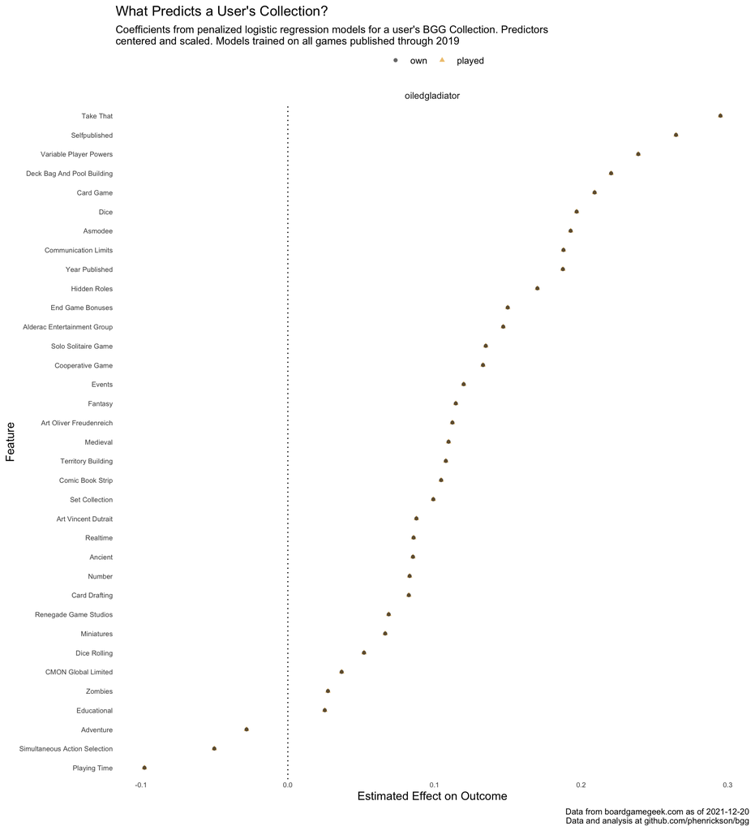

## 2.2 Visualizing Predictors for oiledgladiator’s Collection

Why did the model identify these features? We can make density plots of the important features for predicting whether the user owned a game. Blue indicates the density for games owned by the user, while grey indicates the density for games not owned by the user.

[figure not shown]

Binary predictors can be difficult to see with this visualization, so we can also directly examine the percentage of games in a user’s collection with a predictor vs the percentage of all games with that predictor.

| username | Feature | % of Games with Feature In_Collection | % of Games with Feature All_Games | Ratio |
| --- | --- | --- | --- | --- |
| oiledgladiator | Hidden Roles | 9.5% | 0.7% | 13.3 |
| oiledgladiator | Selfpublished | 14.3% | 1.4% | 10.2 |
| oiledgladiator | Communication Limits | 9.5% | 1.0% | 9.7 |
| oiledgladiator | End Game Bonuses | 9.5% | 1.3% | 7.4 |
| oiledgladiator | Comic Book Strip | 9.5% | 1.4% | 7.0 |
| oiledgladiator | Realtime | 4.8% | 0.7% | 6.8 |
| oiledgladiator | Alderac Entertainment Group | 9.5% | 1.6% | 6.1 |
| oiledgladiator | Renegade Game Studios | 4.8% | 0.9% | 5.3 |
| oiledgladiator | Number | 4.8% | 0.9% | 5.2 |
| oiledgladiator | Take That | 33.3% | 6.6% | 5.0 |
| oiledgladiator | Deck Bag And Pool Building | 23.8% | 4.8% | 4.9 |
| oiledgladiator | Events | 9.5% | 1.9% | 4.9 |
| oiledgladiator | Asmodee | 23.8% | 5.4% | 4.4 |
| oiledgladiator | Solo Solitaire Game | 23.8% | 5.9% | 4.0 |
| oiledgladiator | Cooperative Game | 28.6% | 8.6% | 3.3 |
| oiledgladiator | Variable Player Powers | 47.6% | 17.0% | 2.8 |
| oiledgladiator | Dice | 23.8% | 8.5% | 2.8 |
| oiledgladiator | Miniatures | 14.3% | 5.4% | 2.7 |
| oiledgladiator | Fantasy | 38.1% | 14.8% | 2.6 |
| oiledgladiator | Territory Building | 9.5% | 3.6% | 2.6 |
| oiledgladiator | Card Drafting | 28.6% | 11.9% | 2.4 |
| oiledgladiator | Medieval | 14.3% | 6.3% | 2.3 |
| oiledgladiator | Ancient | 9.5% | 4.5% | 2.1 |
| oiledgladiator | Card Game | 61.9% | 31.0% | 2.0 |
| oiledgladiator | Set Collection | 33.3% | 17.6% | 1.9 |

# 3 Assess Model’s Performance on Training Set

Before predicting games in upcoming years, we can examine how well the model did and what games it liked in the training set. In this case, we used resampling techniques (cross validation) to ensure that the model had not seen a game before making its predictions.

## 3.1 Separation Plot

An easy way to examine the performance of classification model is to view a separation plot. We plot the predicted probabilities from the model for every game (from resampling) from lowest to highest. We then overlay a blue line for any game that the user does own. A good classifier is one that is able to *separate* the blue (games owned by the user) from the white (games not owned by the user), with most of the blue occurring at the highest probabilities (right side of the chart).

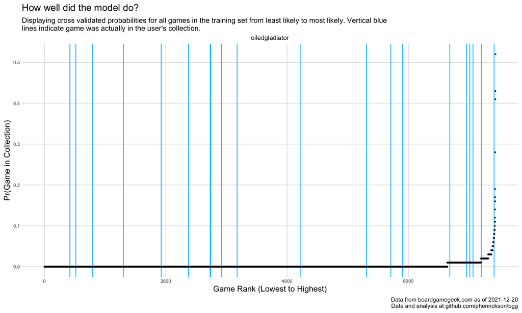

## 3.2 Top Games for **oiledgladiator** from Training Set

We can display this information in table form, displaying the 100 games with the highest probability of ownership, adding a blue line when the user does own the game.

| username | yearpublished | game_id | name | pred_played | pred_own | actual_played | actual_own |
| --- | --- | --- | --- | --- | --- | --- | --- |
| oiledgladiator | 2017 | 211534 | Bears vs Babies | 0.52 | 0.52 | 0 | 0 |
| oiledgladiator | 2019 | 266507 | Clank!: Legacy – Acquisitions Incorporated | 0.43 | 0.43 | 0 | 0 |
| oiledgladiator | 2019 | 271754 | Spire's End | 0.41 | 0.41 | 0 | 0 |
| oiledgladiator | 2018 | 205896 | Rising Sun | 0.28 | 0.28 | 0 | 0 |
| oiledgladiator | 2011 | 88408 | Nightfall | 0.19 | 0.19 | 0 | 0 |
| oiledgladiator | 2015 | 173090 | The Game | 0.17 | 0.17 | 0 | 0 |
| oiledgladiator | 2015 | 172242 | Exploding Kittens: NSFW Deck | 0.16 | 0.16 | 0 | 0 |
| oiledgladiator | 2004 | 9220 | Saboteur | 0.14 | 0.14 | 0 | 0 |
| oiledgladiator | 2016 | 167791 | Terraforming Mars | 0.12 | 0.12 | 0 | 0 |
| oiledgladiator | 2012 | 122522 | Smash Up | 0.11 | 0.11 | 0 | 0 |
| oiledgladiator | 2017 | 209778 | Magic Maze | 0.11 | 0.11 | 0 | 0 |
| oiledgladiator | 2005 | 15062 | Shadows over Camelot | 0.10 | 0.10 | 0 | 0 |
| oiledgladiator | 2019 | 276830 | Sanctum | 0.09 | 0.09 | 0 | 0 |
| oiledgladiator | 2018 | 224710 | Zombicide: Green Horde | 0.09 | 0.09 | 0 | 0 |
| oiledgladiator | 1986 | 925 | Werewolf | 0.09 | 0.09 | 0 | 0 |
| oiledgladiator | 2016 | 205059 | Mansions of Madness: Second Edition | 0.09 | 0.09 | 0 | 0 |
| oiledgladiator | 2015 | 163967 | Tiny Epic Galaxies | 0.09 | 0.09 | 0 | 0 |
| oiledgladiator | 2015 | 171273 | FUSE | 0.09 | 0.09 | 0 | 0 |
| oiledgladiator | 2014 | 160018 | Smash Up: Monster Smash | 0.08 | 0.08 | 0 | 0 |
| oiledgladiator | 2015 | 182260 | Agent Decker | 0.08 | 0.08 | 0 | 0 |
| oiledgladiator | 2018 | 245928 | Pax Emancipation | 0.08 | 0.08 | 0 | 0 |
| oiledgladiator | 2002 | 3955 | BANG! | 0.08 | 0.08 | 0 | 0 |
| oiledgladiator | 2017 | 230667 | Itchy Feet: the Travel Game | 0.08 | 0.08 | 0 | 0 |
| oiledgladiator | 2019 | 283863 | The Magnificent | 0.07 | 0.07 | 0 | 0 |
| oiledgladiator | 2019 | 251551 | Dale of Merchants Collection | 0.07 | 0.07 | 0 | 0 |
| oiledgladiator | 2015 | 175223 | Valley of the Kings: Afterlife | 0.07 | 0.07 | 0 | 0 |
| oiledgladiator | 2018 | 237211 | Valhalla | 0.07 | 0.07 | 0 | 0 |
| oiledgladiator | 2019 | 265736 | Tiny Towns | 0.07 | 0.07 | 0 | 0 |
| oiledgladiator | 1959 | 7688 | Memory | 0.07 | 0.07 | 0 | 0 |
| oiledgladiator | 2018 | 236457 | Architects of the West Kingdom | 0.07 | 0.07 | 0 | 0 |

[output cut: 70 more lines]

We can also more formally assess how well the model did in resampling by looking at the area under the receiver operating characteristic. A perfect model would receive a score of 1, while a model that cannot predict the outcome will default to a score of 0.5. The extent to which something is a *good* score depends on the setting, but generally anything in the .8 to .9 range is very good while the .7 to .8 range is perfectly acceptable.

| username | outcome_type | .metric | .estimator | .estimate |
| --- | --- | --- | --- | --- |
| oiledgladiator | own | roc_auc | binary | 0.782 |
| oiledgladiator | played | roc_auc | binary | 0.782 |

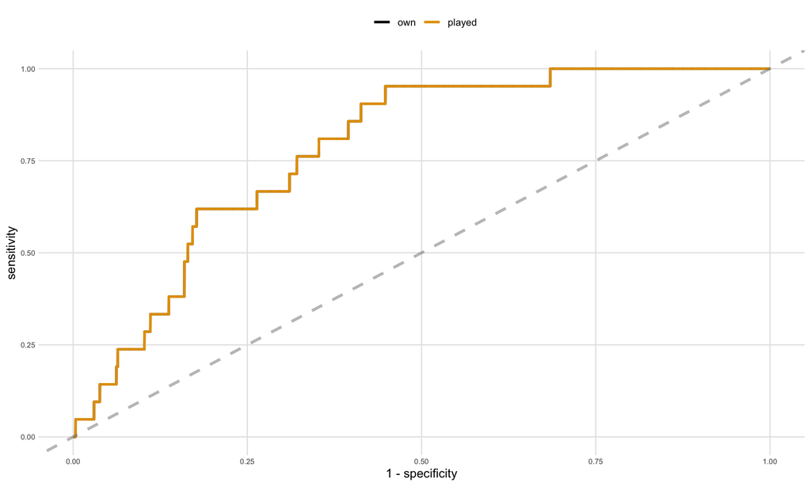

Another way to think about the model performance is to view its lift, or its ability to detect the positive outcomes over that of a null model. High lift indicates the model can much more quickly find all of the positive outcomes (in this case, games owned or played by the user), while a model with no lift is no better than random guessing.

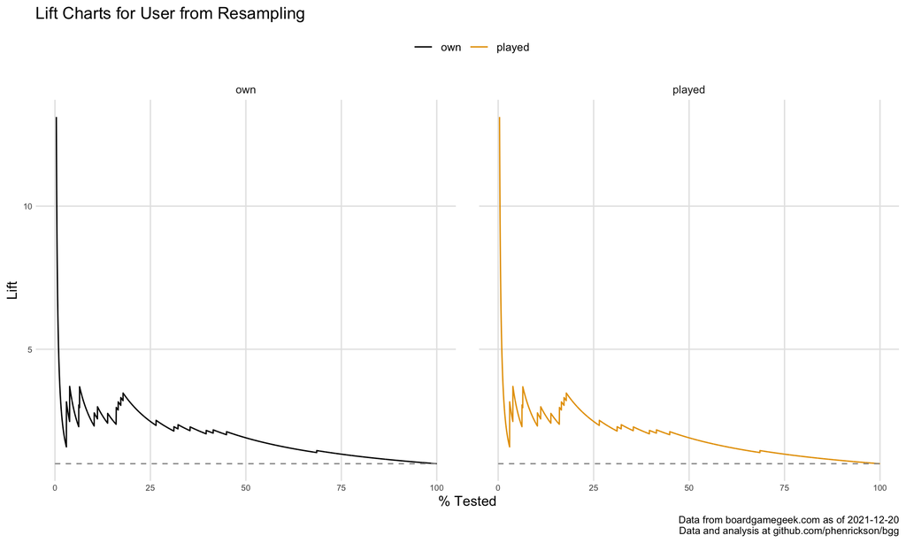

## 3.3 Most and Least Likely Games

What games does the model think oiledgladiator is **most likely to own** that are **not** in their collection?

| username | yearpublished | game_id | name | pred_own | actual_own |
| --- | --- | --- | --- | --- | --- |
| oiledgladiator | 2017 | 211534 | Bears vs Babies | 0.52 | 0 |
| oiledgladiator | 2019 | 266507 | Clank!: Legacy – Acquisitions Incorporated | 0.43 | 0 |
| oiledgladiator | 2019 | 271754 | Spire's End | 0.41 | 0 |
| oiledgladiator | 2018 | 205896 | Rising Sun | 0.28 | 0 |
| oiledgladiator | 2011 | 88408 | Nightfall | 0.19 | 0 |

What games does the model think oiledgladiator is **least likely to own** that **are** in their collection?

| username | yearpublished | game_id | name | pred_own | actual_own |
| --- | --- | --- | --- | --- | --- |
| oiledgladiator | 2018 | 266966 | Dice Throne: Season Two – Gunslinger v. Samurai | 0 | 1 |
| oiledgladiator | 2018 | 266967 | Dice Throne: Season Two – Cursed Pirate v. Artificer | 0 | 1 |
| oiledgladiator | 2009 | 54043 | Jaipur | 0 | 1 |
| oiledgladiator | 2016 | 195544 | Tides of Madness | 0 | 1 |
| oiledgladiator | 2018 | 222509 | Lords of Hellas | 0 | 1 |

## 3.4 Top Games by Year

Top 25 games most likely to be owned by the user in each year, highlighting in blue the games that the user has owned/played.

| rank | 2011 | 2012 | 2013 | 2014 | 2015 | 2016 | 2017 | 2018 | 2019 |
| --- | --- | --- | --- | --- | --- | --- | --- | --- | --- |
| 1 | Nightfall | Smash Up | Mascarade | Smash Up: Monster Smash | The Game | Terraforming Mars | Bears vs Babies | Rising Sun | Clank!: Legacy – Acquisitions Incorporated |
| 2 | Takenoko | Freedom: The Underground Railroad | BANG! The Dice Game | Marrying Mr. Darcy | Exploding Kittens: NSFW Deck | Mansions of Madness: Second Edition | Magic Maze | Zombicide: Green Horde | Spire's End |
| 3 | Mage Knight Board Game | The Resistance: Avalon | A Study in Emerald | Valley of the Kings | Tiny Epic Galaxies | Clank!: A Deck-Building Adventure | Itchy Feet: the Travel Game | Pax Emancipation | Sanctum |
| 4 | Nightfall: Martial Law | Miskatonic School for Girls | Crossing | Spurs: A Tale in the Old West | FUSE | Valeria: Card Kingdoms | Bunny Kingdom | Valhalla | The Magnificent |
| 5 | Penny Arcade: The Game – Gamers vs. Evil | Munchkin Conan | Pathfinder Adventure Card Game: Rise of the Runelords – Base Set | Legendary Encounters: An Alien Deck Building Game | Agent Decker | Pathfinder Adventure Card Game: Mummy's Mask – Base Set | Unstable Unicorns | Architects of the West Kingdom | Dale of Merchants Collection |
| 6 | Elder Sign | Mice and Mystics | Munchkin Legends | Star Realms | Valley of the Kings: Afterlife | Citadels | The Shipwreck Arcana | Star Realms: Frontiers | Tiny Towns |
| 7 | Thunderstone: Dragonspire | Resident Evil Deck Building Game: Mercenaries | Smash Up: Awesome Level 9000 | Imperial Settlers | Exploding Kittens | Scythe | Smash Up: What Were We Thinking? | Nemesis | Hellenica: Story of Greece |
| 8 | A Few Acres of Snow | Penny Arcade: The Game – Rumble in R'lyeh | Pizza Party | Sons of Anarchy: Men of Mayhem | Elysium | Smash Up: Cease and Desist | Masmorra: Dungeons of Arcadia | Street Masters | Aerion |
| 9 | Ascension: Return of the Fallen | Love Letter | City of Remnants | Five Tribes | Burgle Bros. | Secret Hitler | Codenames: Duet | Goblivion | Aeon's End: Legacy |
| 10 | Gears of War: The Board Game | One Night Werewolf | Legacy: The Testament of Duke de Crecy | Arcadia Quest | Smash Up: Munchkin | Thief's Market | D100 Dungeon | The Grizzled: Armistice Edition | Eternal: Chronicles of the Throne |
| 11 | The Red Dragon Inn 3 | Legendary: A Marvel Deck Building Game | Guildhall: Job Faire | Machina Arcana | A Study in Emerald (Second Edition) | Bloodborne: The Card Game | Scott Pilgrim's Precious Little Card Game | Dice Throne: Season Two – Seraph v. Vampire Lord | Silver & Gold |
| 12 | Discworld: Ankh-Morpork | Nightfall: The Coldest War | Maximum Throwdown | Play Me: Alice in Wonderdice | Star Realms: Colony Wars | The Manhattan Project: Energy Empire | Dice Forge | Human Punishment: Social Deduction 2.0 | Llamas Unleashed |
| 13 | Heart of Crown | Rent a Hero | Thunderstone Advance: Numenera | Smash Up: Science Fiction Double Feature | X-Men: Mutant Revolution | Smash Up: It's Your Fault! | Ex Libris | Space Base | It's a Wonderful World |
| 14 | Resident Evil Deck Building Game: Alliance | Targi | Tales & Games: The Three Little Pigs | Trains: Rising Sun | Dice City | One Deck Dungeon | My Little Scythe | Maiden's Quest | Harry Potter: Hogwarts Battle – Defence Against the Dark Arts |
| 15 | Ninja: Legend of the Scorpion Clan | For the Crown (Second Edition) | Dicht dran | Witness | Heroes | Gorechosen | Unreal Estate | 5-Minute Marvel | Unmatched: Robin Hood vs. Bigfoot |
| 16 | Terra Evolution | Urbion | Dungeon Twister: The Card Game | Good Cop Bad Cop | Dale of Merchants | Hit Z Road | Smash Up: Big in Japan | The Legend of Korra: Pro-Bending Arena | Aquatica |
| 17 | TSCHAK! | Suburbia | Smash Up: The Obligatory Cthulhu Set | Thunderstone Advance: Worlds Collide | Epic PVP: Fantasy | Aeon's End | One Deck Dungeon: Forest of Shadows | Dice Throne: Season Two – Tactician v. Huntress | Last Bastion |
| 18 | Eaten by Zombies! | Seasons | Hoplomachus: Rise of Rome | Consentacle | Eight Epics | Harry Potter: Hogwarts Battle | Tesla vs. Edison: Duel | Orchard: A 9 card solitaire game | Rurik: Dawn of Kiev |
| 19 | Carnival | Il Vecchio | Ascension: Darkness Unleashed | Draco Magi | Karnivore Koala | Guildhall Fantasy: Coalition | The Game: Face to Face | Thunderstone Quest | Obscurio |
| 20 | Ascension: Storm of Souls | Trains | Field of Glory: The Card Game | DC Comics Deck-Building Game: Rivals – Batman vs The Joker | The Big Book of Madness | Valley of the Kings: Last Rites | Raging Bulls | Everdell | Zombicide: Invader |
| 21 | The Road to Canterbury | Uncharted: The Board Game | Cube Quest | Onirim (Second Edition) | The Grizzled | Behind the Throne | Fate of the Elder Gods | Star Scrappers: Cave-in | Zombicide: Dark Side |
| 22 | Dark Moon | Hooyah: Navy Seals Card Game | The Witches: A Discworld Game | Pathfinder Adventure Card Game: Skull & Shackles – Base Set | Sylvion | Dale of Merchants 2 | The Masters' Trials: Wrath of Magmaroth | Dice Settlers | Siege Storm |
| 23 | The Walking Dead: The Board Game | IOTA | Eight-Minute Empire: Legends | Shadowrun: Crossfire | KUNE v LAKIA: A Chronicle Of A Royal Lapine Divorce Foretold | Hero Realms | Pendragon: The Fall of Roman Britain | Heroes of Terrinoth | Circadians: First Light |
| 24 | Dungeon Fighter | Teomachia | Berserk: War of the Realms | Roll Through the Ages: The Iron Age | Raptor | Kung Fu Zoo | Gaia Project | Azul: Stained Glass of Sintra | Orléans Stories |
| 25 | Flash Point: Fire Rescue | Robinson Crusoe: Adventures on the Cursed Island | Justice League: Axis of Villains Strategy Game | Abyss | Epic Card Game | Mega Man: The Board Game | Spirit Island | Walking in Burano | Call to Adventure |

## 3.5 Interactive Predictions from Resampling

Interactive table for predictions from resampling.

|  | username | yearpublished | rank | game_id | name | pred_played | pred_own | actual_played | actual_own |
| --- | --- | --- | --- | --- | --- | --- | --- | --- | --- |
| 1 | oiledgladiator | 1900 | 46 | 10799 | Old Maid | 0.05 | 0.05 | 0 | 0 |
| 2 | oiledgladiator | 1900 | 427 | 9851 | Shut the Box | 0.01 | 0.01 | 0 | 0 |
| 3 | oiledgladiator | 1900 | 628 | 45 | Perudo | 0.01 | 0.01 | 0 | 0 |
| 4 | oiledgladiator | 1900 | 656 | 2785 | Game of Goose | 0.01 | 0.01 | 0 | 0 |
| 5 | oiledgladiator | 1900 | 807 | 5546 | Marbles | 0 | 0 | 0 | 0 |
| 6 | oiledgladiator | 1900 | 810 | 11901 | Tic-Tac-Toe | 0 | 0 | 0 | 0 |
| 7 | oiledgladiator | 1900 | 857 | 188 | Go | 0 | 0 | 0 | 0 |
| 8 | oiledgladiator | 1900 | 971 | 171 | Chess | 0 | 0 | 0 | 0 |
| 9 | oiledgladiator | 1900 | 982 | 2065 | Shogi | 0 | 0 | 0 | 0 |
| 10 | oiledgladiator | 1900 | 984 | 2393 | Xiangqi | 0 | 0 | 0 | 0 |

[output cut: 7426 more lines]

# 4 Validating the Model on 2020

How well did a model trained on a user’s collection through 2019 perform in predicting games for the user from 2020?

| username | outcome_type | yearpublished | .metric | .estimator | .estimate |
| --- | --- | --- | --- | --- | --- |
| oiledgladiator | own | 2020 | roc_auc | binary | 0.779 |
| oiledgladiator | played | 2020 | roc_auc | binary | 0.779 |

Table of top 25 games from 2020, highlighting games that the user owns.

| username | yearpublished | game_id | name | pred_own | pred_played | actual_own | actual_played |
| --- | --- | --- | --- | --- | --- | --- | --- |
| oiledgladiator | 2020 | 256317 | Guild Master | 0.12 | 0.12 | 0 | 0 |
| oiledgladiator | 2020 | 292684 | Mindburners | 0.10 | 0.10 | 0 | 0 |
| oiledgladiator | 2020 | 302193 | Wonder Woman: Challenge of the Amazons | 0.08 | 0.08 | 0 | 0 |
| oiledgladiator | 2020 | 296151 | Viscounts of the West Kingdom | 0.07 | 0.07 | 0 | 0 |
| oiledgladiator | 2020 | 291457 | Gloomhaven: Jaws of the Lion | 0.06 | 0.06 | 1 | 1 |
| oiledgladiator | 2020 | 261403 | Inhuman Conditions | 0.05 | 0.05 | 0 | 0 |
| oiledgladiator | 2020 | 248072 | Don't Let It Die | 0.04 | 0.04 | 0 | 0 |
| oiledgladiator | 2020 | 287088 | Block Happy | 0.04 | 0.04 | 0 | 0 |
| oiledgladiator | 2020 | 288513 | Tranquility | 0.04 | 0.04 | 0 | 0 |
| oiledgladiator | 2020 | 302465 | Obsidia | 0.04 | 0.04 | 0 | 0 |
| oiledgladiator | 2020 | 309600 | Archers of Nand | 0.04 | 0.04 | 0 | 0 |
| oiledgladiator | 2020 | 311751 | I Am Death Now? | 0.04 | 0.04 | 0 | 0 |
| oiledgladiator | 2020 | 316554 | Dune: Imperium | 0.04 | 0.04 | 0 | 0 |
| oiledgladiator | 2020 | 323784 | Ghost Letters | 0.04 | 0.04 | 0 | 0 |
| oiledgladiator | 2020 | 266188 | Seven Bridges | 0.03 | 0.03 | 0 | 0 |
| oiledgladiator | 2020 | 273703 | Altar Quest | 0.03 | 0.03 | 0 | 0 |
| oiledgladiator | 2020 | 288169 | The Fox in the Forest Duet | 0.03 | 0.03 | 0 | 0 |
| oiledgladiator | 2020 | 296605 | Adventure of D (Second Edition) | 0.03 | 0.03 | 0 | 0 |
| oiledgladiator | 2020 | 302840 | Carcata | 0.03 | 0.03 | 0 | 0 |
| oiledgladiator | 2020 | 313698 | Monster Expedition | 0.03 | 0.03 | 0 | 0 |
| oiledgladiator | 2020 | 177014 | Giga-Robo! | 0.02 | 0.02 | 0 | 0 |
| oiledgladiator | 2020 | 245659 | Vampire: The Masquerade – Vendetta | 0.02 | 0.02 | 0 | 0 |
| oiledgladiator | 2020 | 256391 | Queen Bee | 0.02 | 0.02 | 0 | 0 |
| oiledgladiator | 2020 | 256609 | Nunami | 0.02 | 0.02 | 0 | 0 |
| oiledgladiator | 2020 | 257145 | Teenage Mutant Ninja Turtles Adventures: City Fall | 0.02 | 0.02 | 0 | 0 |

# 5 Predicting Upcoming Games (2020 and On) for **oiledgladiator**

Examine the top games for the test set.

| username | yearpublished | game_id | name | rank | own | played |
| --- | --- | --- | --- | --- | --- | --- |
| oiledgladiator | 2020 | 256317 | Guild Master | 1 | 0.12 | 0.12 |
| oiledgladiator | 2020 | 292684 | Mindburners | 2 | 0.10 | 0.10 |
| oiledgladiator | 2020 | 302193 | Wonder Woman: Challenge of the Amazons | 3 | 0.08 | 0.08 |
| oiledgladiator | 2020 | 296151 | Viscounts of the West Kingdom | 4 | 0.07 | 0.07 |
| oiledgladiator | 2020 | 291457 | Gloomhaven: Jaws of the Lion | 5 | 0.06 | 0.06 |
| oiledgladiator | 2020 | 261403 | Inhuman Conditions | 6 | 0.05 | 0.05 |
| oiledgladiator | 2020 | 311751 | I Am Death Now? | 7 | 0.04 | 0.04 |
| oiledgladiator | 2020 | 248072 | Don't Let It Die | 8 | 0.04 | 0.04 |
| oiledgladiator | 2020 | 316554 | Dune: Imperium | 9 | 0.04 | 0.04 |
| oiledgladiator | 2020 | 302465 | Obsidia | 10 | 0.04 | 0.04 |
| oiledgladiator | 2020 | 323784 | Ghost Letters | 11 | 0.04 | 0.04 |
| oiledgladiator | 2020 | 288513 | Tranquility | 12 | 0.04 | 0.04 |
| oiledgladiator | 2020 | 309600 | Archers of Nand | 13 | 0.04 | 0.04 |
| oiledgladiator | 2020 | 287088 | Block Happy | 14 | 0.04 | 0.04 |
| oiledgladiator | 2020 | 266188 | Seven Bridges | 15 | 0.03 | 0.03 |
| oiledgladiator | 2020 | 273703 | Altar Quest | 16 | 0.03 | 0.03 |
| oiledgladiator | 2020 | 296605 | Adventure of D (Second Edition) | 17 | 0.03 | 0.03 |
| oiledgladiator | 2020 | 302840 | Carcata | 18 | 0.03 | 0.03 |
| oiledgladiator | 2020 | 288169 | The Fox in the Forest Duet | 19 | 0.03 | 0.03 |
| oiledgladiator | 2020 | 313698 | Monster Expedition | 20 | 0.03 | 0.03 |
| oiledgladiator | 2020 | 291874 | Dwergar | 21 | 0.02 | 0.02 |
| oiledgladiator | 2020 | 266993 | Call to Adventure: The Stormlight Archive | 22 | 0.02 | 0.02 |
| oiledgladiator | 2020 | 282765 | Mint Cooperative | 23 | 0.02 | 0.02 |
| oiledgladiator | 2020 | 257145 | Teenage Mutant Ninja Turtles Adventures: City Fall | 24 | 0.02 | 0.02 |
| oiledgladiator | 2020 | 300731 | Valknut | 25 | 0.02 | 0.02 |
| oiledgladiator | 2021 | 298102 | Roll Camera!: The Filmmaking Board Game | 1 | 0.36 | 0.36 |
| oiledgladiator | 2021 | 313085 | Sleep Tight | 2 | 0.06 | 0.06 |
| oiledgladiator | 2021 | 329465 | Red Rising | 3 | 0.05 | 0.05 |
| oiledgladiator | 2021 | 265771 | Dance Card! | 4 | 0.05 | 0.05 |
| oiledgladiator | 2021 | 277469 | The Phantom: The Card Game | 5 | 0.05 | 0.05 |
| oiledgladiator | 2021 | 323898 | Doom Machine | 6 | 0.04 | 0.04 |
| oiledgladiator | 2021 | 251661 | Oathsworn: Into the Deepwood | 7 | 0.04 | 0.04 |
| oiledgladiator | 2021 | 299566 | Batman: The Animated Series Adventures – Shadow of the Bat | 8 | 0.04 | 0.04 |
| oiledgladiator | 2021 | 314393 | Wutaki | 9 | 0.04 | 0.04 |
| oiledgladiator | 2021 | 306697 | Smash Up: Marvel | 10 | 0.04 | 0.04 |
| oiledgladiator | 2021 | 283387 | Rocketmen | 11 | 0.03 | 0.03 |
| oiledgladiator | 2021 | 314589 | Night Parade of a Hundred Yokai | 12 | 0.03 | 0.03 |
| oiledgladiator | 2021 | 273330 | Bloodborne: The Board Game | 13 | 0.03 | 0.03 |
| oiledgladiator | 2021 | 310641 | Ostium | 14 | 0.03 | 0.03 |
| oiledgladiator | 2021 | 318184 | Imperium: Classics | 15 | 0.03 | 0.03 |
| oiledgladiator | 2021 | 335541 | We Care: a Grizzled Game | 16 | 0.03 | 0.03 |
| oiledgladiator | 2021 | 320446 | Corduba 27 a.C. | 17 | 0.03 | 0.03 |
| oiledgladiator | 2021 | 331787 | Tiny Epic Dungeons | 18 | 0.02 | 0.02 |
| oiledgladiator | 2021 | 340237 | Wonder Book | 19 | 0.02 | 0.02 |
| oiledgladiator | 2021 | 308989 | Bristol 1350 | 20 | 0.02 | 0.02 |
| oiledgladiator | 2021 | 348955 | Rock Paper Scissors: Deluxe Edition | 21 | 0.02 | 0.02 |
| oiledgladiator | 2021 | 302461 | Intrepid | 22 | 0.02 | 0.02 |
| oiledgladiator | 2021 | 206757 | Glory: A Game of Knights | 23 | 0.02 | 0.02 |
| oiledgladiator | 2021 | 310100 | Nemesis: Lockdown | 24 | 0.02 | 0.02 |
| oiledgladiator | 2021 | 291847 | Mantis Falls | 25 | 0.02 | 0.02 |
| oiledgladiator | 2022 | 295770 | Frosthaven | 1 | 0.07 | 0.07 |
| oiledgladiator | 2022 | 331106 | The Witcher: Old World | 2 | 0.06 | 0.06 |
| oiledgladiator | 2022 | 304051 | Creature Comforts | 3 | 0.04 | 0.04 |
| oiledgladiator | 2022 | 339592 | Sheep in Disguise | 4 | 0.04 | 0.04 |
| oiledgladiator | 2022 | 342246 | Feuding Foodies | 5 | 0.03 | 0.03 |
| oiledgladiator | 2022 | 320718 | Hidden Leaders | 6 | 0.03 | 0.03 |
| oiledgladiator | 2022 | 333255 | Keep the Heroes Out! | 7 | 0.03 | 0.03 |
| oiledgladiator | 2022 | 317511 | Tindaya | 8 | 0.02 | 0.02 |
| oiledgladiator | 2022 | 284118 | Mechanical Beast | 9 | 0.02 | 0.02 |
| oiledgladiator | 2022 | 271601 | Feed the Kraken | 10 | 0.02 | 0.02 |
| oiledgladiator | 2022 | 280726 | Legacies | 11 | 0.02 | 0.02 |
| oiledgladiator | 2022 | 305096 | Endless Winter: Paleoamericans | 12 | 0.02 | 0.02 |
| oiledgladiator | 2022 | 288080 | Dice Realms | 13 | 0.01 | 0.01 |
| oiledgladiator | 2022 | 315610 | Massive Darkness 2: Hellscape | 14 | 0.01 | 0.01 |
| oiledgladiator | 2022 | 319807 | Shogun no Katana | 15 | 0.01 | 0.01 |
| oiledgladiator | 2022 | 303731 | Primal: The Awakening | 16 | 0.01 | 0.01 |
| oiledgladiator | 2022 | 294529 | Entropia: The Game | 17 | 0.01 | 0.01 |
| oiledgladiator | 2022 | 317321 | Darkest Dungeon: The Board Game | 18 | 0.01 | 0.01 |
| oiledgladiator | 2022 | 334065 | Verdant | 19 | 0.01 | 0.01 |
| oiledgladiator | 2022 | 294880 | Chai: Tea for 2 | 20 | 0.01 | 0.01 |
| oiledgladiator | 2022 | 240980 | Blood on the Clocktower | 21 | 0.01 | 0.01 |
| oiledgladiator | 2022 | 274471 | Malhya: Lands of Legends | 22 | 0.01 | 0.01 |
| oiledgladiator | 2022 | 276182 | Dead Reckoning | 23 | 0.01 | 0.01 |
| oiledgladiator | 2022 | 324090 | Scarface 1920 | 24 | 0.01 | 0.01 |
| oiledgladiator | 2022 | 256680 | Return to Dark Tower | 25 | 0.01 | 0.01 |

## 5.1 Interactive Table for Upcoming Games 2020 and On

|  | username | yearpublished | game_id | name | rank | own | played |
| --- | --- | --- | --- | --- | --- | --- | --- |
| 1 | oiledgladiator | 2021 | 298102 | Roll Camera!: The Filmmaking Board Game | 1 | 0.36 | 0.36 |
| 2 | oiledgladiator | 2020 | 256317 | Guild Master | 2 | 0.12 | 0.12 |
| 3 | oiledgladiator | 2020 | 292684 | Mindburners | 3 | 0.1 | 0.1 |
| 4 | oiledgladiator | 2020 | 302193 | Wonder Woman: Challenge of the Amazons | 4 | 0.08 | 0.08 |
| 5 | oiledgladiator | 2022 | 295770 | Frosthaven | 5 | 0.07 | 0.07 |
| 6 | oiledgladiator | 2020 | 296151 | Viscounts of the West Kingdom | 6 | 0.07 | 0.07 |
| 7 | oiledgladiator | 2022 | 331106 | The Witcher: Old World | 7 | 0.06 | 0.06 |
| 8 | oiledgladiator | 2020 | 291457 | Gloomhaven: Jaws of the Lion | 8 | 0.06 | 0.06 |
| 9 | oiledgladiator | 2021 | 313085 | Sleep Tight | 9 | 0.06 | 0.06 |
| 10 | oiledgladiator | 2021 | 329465 | Red Rising | 10 | 0.05 | 0.05 |

[output cut: 1627 more lines]